# UK Household Annual expenditure Analysis

### Model evaluation

The following functions will be used to evaluate the models.

```r
get_bp_decision = function(model, alpha = 0.01) {
  decide = unname(bptest(model)$p.value < alpha)
  ifelse(decide, "Reject", "Fail to Reject")
}

get_sw_decision = function(model, alpha = 0.01) {
 decide = unname(shapiro.test(resid(model))$p.value < alpha)
 ifelse(decide, "Reject", "Fail to Reject")
}

get_loocv_rmse = function(model) {
  sqrt(mean((resid(model) / (1 - hatvalues(model))) ^ 2))
}

get_rmse = function(model) {
  mean(model$residuals ^ 2)
}

get_adj_r2 = function(model) {
  summary(model)$adj.r.squared
}

# This function takes the model as the input and test
# a) Normality
# b) Linearity
# c) Constant variance
assumption_test = function(model){
  par(mfrow=c(1,2))

  # Fitted vs residual plot
  plot(fitted.values(model),resid(model),col="dodgerblue", xlab = "Fitted", ylab = "Residuals", main = "Fitted vs Residuals")
  abline(h=0,col="red",lwd=2)

  # QQ plot to test normality
  qqnorm(resid(model),col="dodgerblue")
  qqline(resid(model),lwd=2,col="red")
}
```

## Exploratory Analysis

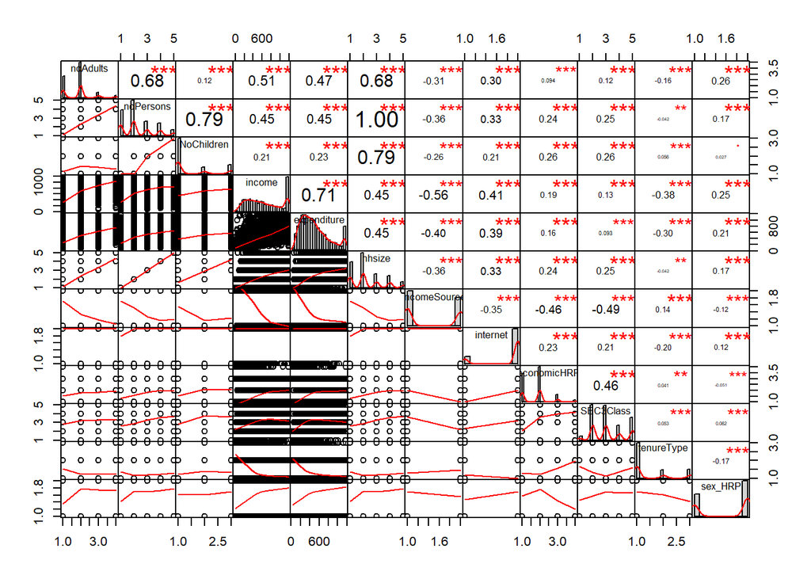

Figure 1 - Correlation and Scatterplot of the variables of the data set

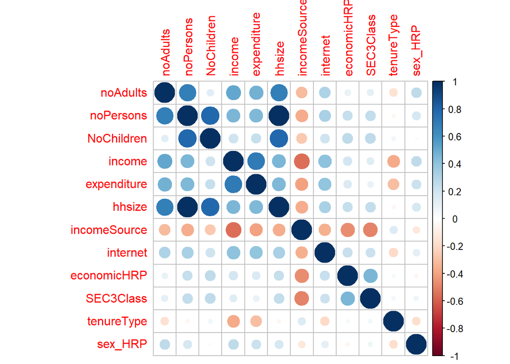

Figure 2 - Correlation matrix for the data set

The correlation and scatter plot shown in Figure 1 shows a strong correlation between `hhsize` and `noPersons`, and to a letter extent with `noAdults`, and `NoChildren`. This is also shown in the correlation matrix of Figure 2.

```r
cor(lcf_data1$hhsize,lcf_data1$noPersons)
```

```
## [1] 1
```

```r
sum(!lcf_data1$hhsize == lcf_data1$noPersons)
```

```
## [1] 0
```

This shows that `hhsize` and `noPersons` have the same data values. Thus `hhsize` will be used as a potential predictor for the model in place of `noPersons`, `noAdults`, and `NoChildren`.

## Model Building

### Simple Model Explanation

Lets create a additive model first

```r
model = lm(expenditure ~ ., data = lcf_data)
summary(model)
```

```
##
## Call:
## lm(formula = expenditure ~ ., data = lcf_data)
##
## Residuals:
##     Min      1Q  Median      3Q     Max
## -578.52 -120.00  -27.83   86.20  919.57
##
## Coefficients: (1 not defined because of singularities)
##                          Estimate Std. Error t value Pr(>|t|)
## (Intercept)              60.66150   22.05238   2.751 0.005966 **
## noAdults2                28.52000   21.26902   1.341 0.180007
## noAdults3                39.76983   35.35560   1.125 0.260704
## noAdults4                45.47659   52.25889   0.870 0.384223
## noPersons2               46.55914   21.67566   2.148 0.031761 *
## noPersons3               82.98810   36.68081   2.262 0.023712 *
## noPersons4              136.57456   53.20639   2.567 0.010290 *
## noPersons5              175.00547   60.34248   2.900 0.003745 **
## NoChildrenOneChild       -4.69700   19.38937  -0.242 0.808599
## NoChildrenTwoOrMore     -40.78070   36.41801  -1.120 0.262854
## income                    0.43526    0.01248  34.875  < 2e-16 ***
## hhsize                         NA         NA      NA       NA
## incomeSourceOtherIncome  25.92481   10.37042   2.500 0.012455 *
## internetYes              62.80894    8.38091   7.494 7.81e-14 ***
## economicHRPFullTime     -17.19410   14.17735  -1.213 0.225268
## economicHRPPartTime       9.46254   14.48035   0.653 0.513480
## economicHRPUnemployed   -28.78424   19.11624  -1.506 0.132194
## SEC3ClassClass 5         -6.80008   18.05257  -0.377 0.706425
## SEC3ClassClass1          60.79293   17.87441   3.401 0.000676 ***
## SEC3ClassClass2          32.90266   18.33272   1.795 0.072753 .
## SEC3ClassClass3         -17.05522   17.47576  -0.976 0.329142
## tenureTypePrivateRented  23.75040    8.23192   2.885 0.003929 **
## tenureTypePublicRented  -42.77353    8.37180  -5.109 3.35e-07 ***
## sex_HRPMale              12.16850    6.28248   1.937 0.052813 .
## ---
## Signif. codes:  0 '***' 0.001 '**' 0.01 '*' 0.05 '.' 0.1 ' ' 1
##
## Residual standard error: 197.3 on 5109 degrees of freedom
## Multiple R-squared:  0.5469, Adjusted R-squared:  0.545
## F-statistic: 280.3 on 22 and 5109 DF,  p-value: < 2.2e-16
```

Selecting only the important variables

```r
model = lm(expenditure ~ income + internet + tenureType + SEC3Class + hhsize, data = lcf_data)

summary(model)
```

```
##
## Call:
## lm(formula = expenditure ~ income + internet + tenureType + SEC3Class +
##     hhsize, data = lcf_data)
##
## Residuals:
##     Min      1Q  Median      3Q     Max
## -579.39 -121.48  -29.19   87.58  928.52
##
## Coefficients:
##                          Estimate Std. Error t value Pr(>|t|)
## (Intercept)              41.33129   17.47126   2.366   0.0180 *
## income                    0.44606    0.01098  40.620  < 2e-16 ***
## internetYes              68.36560    8.31054   8.226 2.42e-16 ***
## tenureTypePrivateRented  18.78568    8.22133   2.285   0.0224 *
## tenureTypePublicRented  -47.90530    8.32056  -5.757 9.04e-09 ***
## SEC3ClassClass 5         14.23394   15.67215   0.908   0.3638
## SEC3ClassClass1          41.49697   16.16857   2.567   0.0103 *
## SEC3ClassClass2          17.96450   16.51211   1.088   0.2767
## SEC3ClassClass3         -25.33816   15.69351  -1.615   0.1065
## hhsize                   41.08388    2.75662  14.904  < 2e-16 ***
## ---
## Signif. codes:  0 '***' 0.001 '**' 0.01 '*' 0.05 '.' 0.1 ' ' 1
##
## Residual standard error: 198.4 on 5122 degrees of freedom
## Multiple R-squared:  0.5405, Adjusted R-squared:  0.5397
## F-statistic: 669.4 on 9 and 5122 DF,  p-value: < 2.2e-16
```

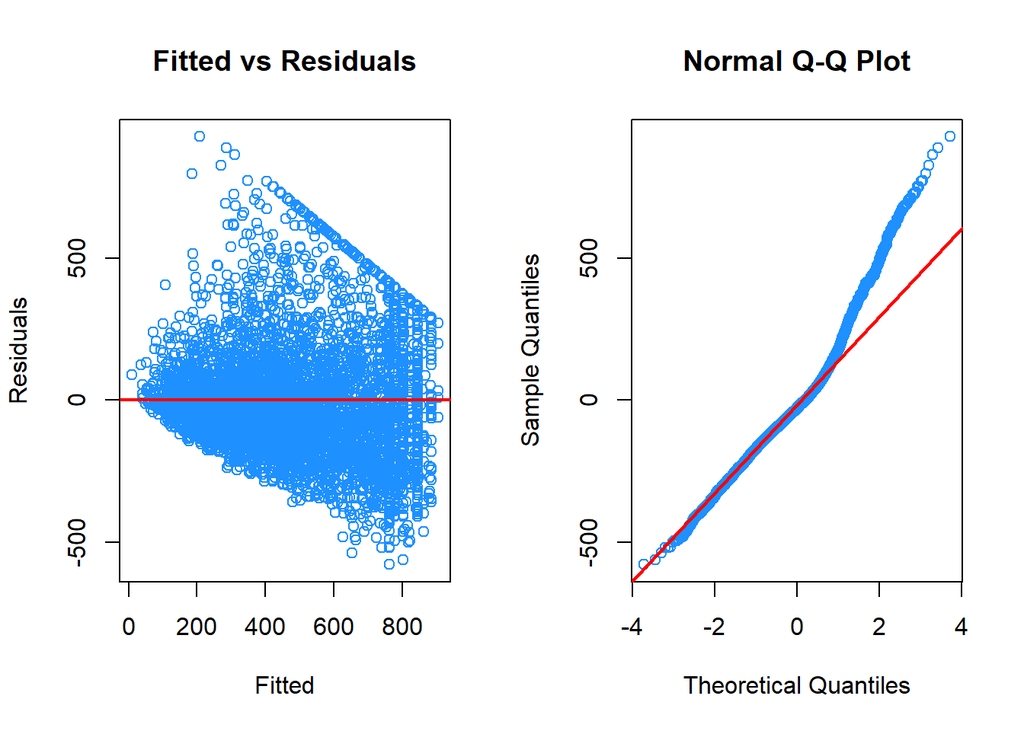

Figure 3 - Residuals vs Fitted and Normal QQ Plot for the model

```r
assumption_test(model)
```

#### Log Transformation

```r
model_log = lm(log(expenditure)~income + internet + tenureType + SEC3Class + hhsize, data = lcf_data)
summary(model_log)
```

```
##
## Call:
## lm(formula = log(expenditure) ~ income + internet + tenureType +
##     SEC3Class + hhsize, data = lcf_data)
##
## Residuals:
##      Min       1Q   Median       3Q      Max
## -1.70182 -0.27556  0.01033  0.26801  1.57680
##
## Coefficients:
##                           Estimate Std. Error t value Pr(>|t|)
## (Intercept)              4.703e+00  3.808e-02 123.519  < 2e-16 ***
## income                   9.742e-04  2.393e-05  40.710  < 2e-16 ***
## internetYes              3.205e-01  1.811e-02  17.696  < 2e-16 ***
## tenureTypePrivateRented  5.190e-02  1.792e-02   2.897  0.00378 **
## tenureTypePublicRented  -1.882e-01  1.813e-02 -10.381  < 2e-16 ***
## SEC3ClassClass 5         1.651e-01  3.415e-02   4.834 1.38e-06 ***
## SEC3ClassClass1          2.162e-01  3.524e-02   6.135 9.17e-10 ***
## SEC3ClassClass2          2.226e-01  3.599e-02   6.186 6.65e-10 ***
## SEC3ClassClass3          1.377e-01  3.420e-02   4.026 5.75e-05 ***
## hhsize                   1.037e-01  6.008e-03  17.267  < 2e-16 ***
## ---
## Signif. codes:  0 '***' 0.001 '**' 0.01 '*' 0.05 '.' 0.1 ' ' 1
##
## Residual standard error: 0.4324 on 5122 degrees of freedom
## Multiple R-squared:  0.6022, Adjusted R-squared:  0.6015
## F-statistic: 861.4 on 9 and 5122 DF,  p-value: < 2.2e-16
```

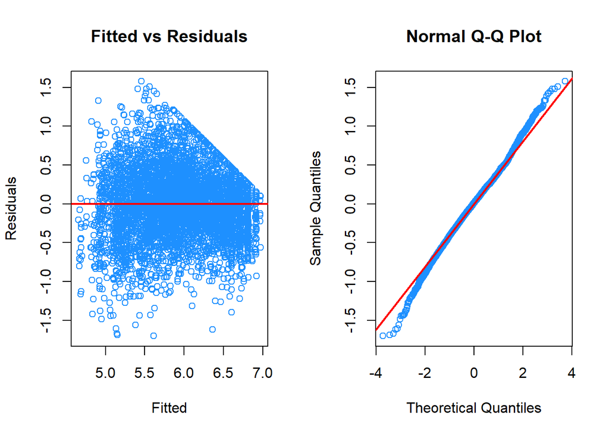

Figure 4 - Residuals vs Fitted and Normal QQ Plot for the log transformed model

```r
assumption_test(model_log)
```

#### BoxCox Transformation

```r
model =lm(expenditure ~ income + internet + tenureType + SEC3Class + hhsize, data = lcf_data)
bc=boxcox(model,lambda = seq(-3,3))
```

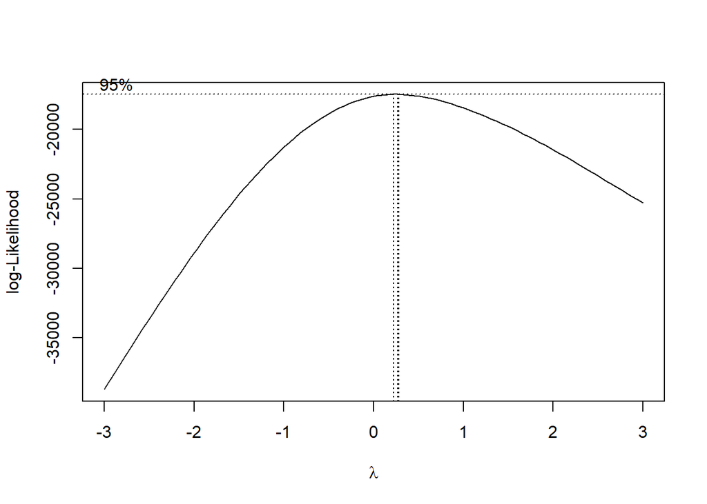

Figure 5 - BoxCox for the simple model

```r
(lambda = best_lambda = bc$x[which(bc$y==max(bc$y))])
```

```
## [1] 0.2727273
```

```r
model = lm(expenditure^lambda ~  income +internet + hhsize + tenureType+SEC3Class, data = lcf_data)
summary(model)
```

```
##
## Call:
## lm(formula = expenditure^lambda ~ income + internet + hhsize +
##     tenureType + SEC3Class, data = lcf_data)
##
## Residuals:
##      Min       1Q   Median       3Q      Max
## -2.08027 -0.39337 -0.02572  0.37219  2.39127
##
## Coefficients:
##                           Estimate Std. Error t value Pr(>|t|)
## (Intercept)              3.543e+00  5.146e-02  68.839  < 2e-16 ***
## income                   1.373e-03  3.235e-05  42.437  < 2e-16 ***
## internetYes              3.712e-01  2.448e-02  15.165  < 2e-16 ***
## hhsize                   1.394e-01  8.120e-03  17.166  < 2e-16 ***
## tenureTypePrivateRented  6.811e-02  2.422e-02   2.813 0.004933 **
## tenureTypePublicRented  -2.238e-01  2.451e-02  -9.131  < 2e-16 ***
## SEC3ClassClass 5         1.643e-01  4.616e-02   3.560 0.000375 ***
## SEC3ClassClass1          2.432e-01  4.763e-02   5.106 3.41e-07 ***
## SEC3ClassClass2          2.261e-01  4.864e-02   4.648 3.44e-06 ***
## SEC3ClassClass3          1.018e-01  4.623e-02   2.201 0.027758 *
## ---
## Signif. codes:  0 '***' 0.001 '**' 0.01 '*' 0.05 '.' 0.1 ' ' 1
##
## Residual standard error: 0.5845 on 5122 degrees of freedom
## Multiple R-squared:  0.602,  Adjusted R-squared:  0.6013
## F-statistic: 860.8 on 9 and 5122 DF,  p-value: < 2.2e-16
```

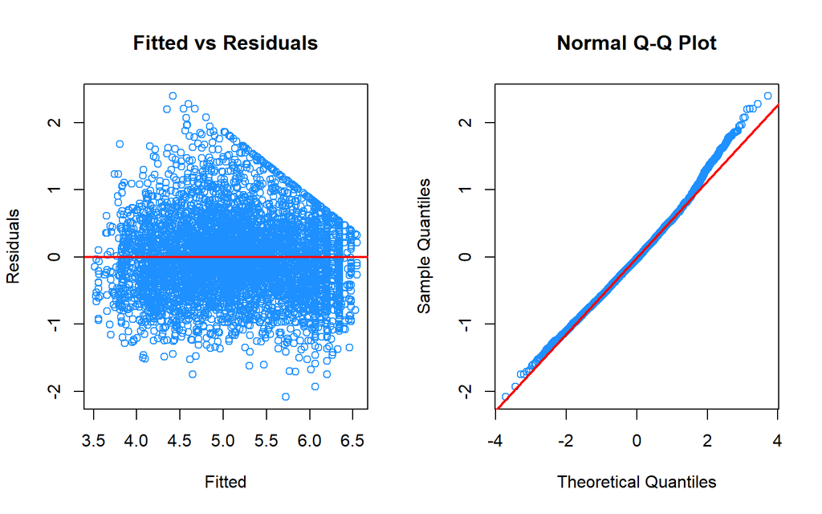

Figure 6 - Residuals vs Fitted and Normal QQ Plot for the BoxCox transformed model

```r
assumption_test(model)
```

Fitted Vs Residual plot looks ok

```r
coef(summary(model))
```

```
##                             Estimate   Std. Error   t value     Pr(>|t|)
## (Intercept)              3.542765119 5.146429e-02 68.839285 0.000000e+00
## income                   0.001372709 3.234683e-05 42.437199 0.000000e+00
## internetYes              0.371238542 2.447999e-02 15.164982 7.561373e-51
## hhsize                   0.139386147 8.120038e-03 17.165702 2.923177e-64
## tenureTypePrivateRented  0.068113677 2.421719e-02  2.812617 4.932721e-03
## tenureTypePublicRented  -0.223785066 2.450949e-02 -9.130549 9.609779e-20
## SEC3ClassClass 5         0.164327686 4.616473e-02  3.559594 3.747976e-04
## SEC3ClassClass1          0.243170256 4.762701e-02  5.105721 3.414637e-07
## SEC3ClassClass2          0.226065984 4.863897e-02  4.647836 3.438520e-06
## SEC3ClassClass3          0.101761949 4.622765e-02  2.201322 2.775767e-02
```

```r
model_train = lm(expenditure^lambda ~  income +internet + hhsize + tenureType+SEC3Class, data = lcf_trn_data)


# Train RMSE
sqrt(mean((predict(model_train)^(1/lambda) - lcf_trn_data$expenditure)^2))
```

```
## [1] 199.7327
```

```r
# Test RMSE
sqrt(mean((predict(model_train,newdata = lcf_tst_data)^(1/lambda) - lcf_tst_data$expenditure)^2))
```

```
## [1] 206.3717
```

### Interaction Model Explanation

Start with a large model,

```r
large_model = lm(expenditure ~ I(income ^ 2) + I(hhsize ^ 2) + (income + hhsize + internet + economicHRP + SEC3Class + tenureType + sex_HRP)^2, data = lcf_trn_data)
```

Performing backward AIC on the model,

```r
large_model_back_aic = step(large_model, direction = "backward", trace = 0)
```

and backward BIC on the model,

```r
large_model_back_bic = step(large_model, direction = "backward", trace = 0, k = log(length(resid(large_model))))
```

The characteristices of the models are

| Characteristic | Large Model | Model from backward AIC | Model from backward BIC |
| --- | --- | --- | --- |
| Number of predictors | 84 | 36 | 19 |
| Adjusted $R^2$ | 0.544511 | 0.5452577 | 0.5408466 |
| LOOCV RMSE |  | 195.8011207 | 196.473215 |
| Shapiro-Wilks Test | Reject | Reject | Reject |
| BP Test | Reject | Reject | Reject |

The model obtained from the backward AIC search has the lower LOOCV RMSE and higher Adjusted $R^2$. It did not pass the Shapiro-Wilks and BP tests. The Fitted vs Residual plot and the Normal QQ Plot (figure 7) were then looked at for this model.

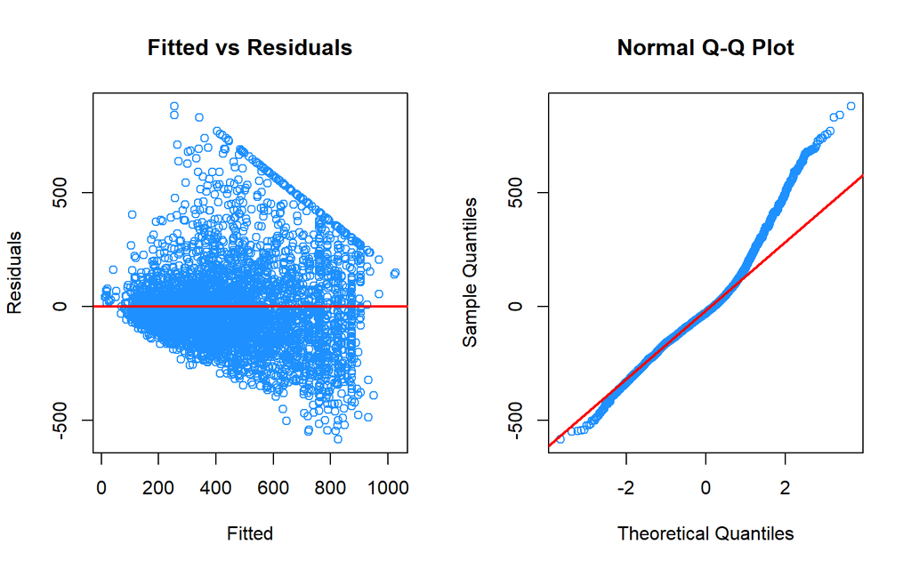

Figure 7 - Residuals vs Fitted and Normal QQ Plot for the model obtained from backward AIC search

```r
assumption_test(large_model_back_aic)
```

Figure 7 shows that the constant variance assumption is violated since there is not an even spread of the residuals about the zero line. The plot also shows that the normality assumption is violated.

These results indicate that a transformation of the response is required. Performing a BoxCox transformation on the model,

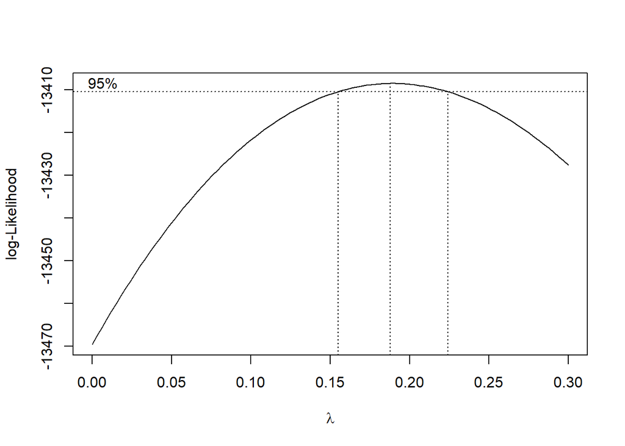

Figure 8

```r
bc = boxcox(large_model_back_aic, plotit = TRUE, lambda = seq(0, 0.3, by = 0.1))
```

```r
inter_lambda = bc$x[which.max(bc$y)]
```

indicates that the value of $\lambda$ in $\frac{{y^\lambda}-1}{\lambda}$ is 0.1878788. Applying this transformation to the large model,

```r
large_model_trans = lm((((expenditure ^ inter_lambda)-1)/inter_lambda) ~ I(income ^ 2) + I(hhsize ^ 2) + (income + hhsize + internet + economicHRP + SEC3Class + tenureType + sex_HRP)^2, data = lcf_trn_data)
```

and performing a backward search using AIC,

```r
large_model_trans_back_aic = step(large_model_trans, direction = "backward", trace = 0)
```

and a backward search using BIC,

```r
large_model_trans_back_bic = step(large_model_trans, direction = "backward", trace = 0, k = log(length(resid(large_model_trans))))
```

yields the following results

| Characteristic | Large Model | Model from backward AIC | Model from backward BIC |
| --- | --- | --- | --- |
| Number of predictors | 84 | 43 | 19 |
| Adjusted $R^2$ | 0.6211511 | 0.6218965 | 0.6150619 |
| LOOCV RMSE |  | 1.263065 | 1.2707634 |
| Shapiro-Wilks Test | Reject | Reject | Reject |
| BP Test | Reject | Reject | Reject |

The LOOCV RMSE values obtained are lower than those obtained before the transformation and the $R^2$ value has increased. The Shapiro-Wilks and the BP tests are not passed by these models however.

The model chosen by the backward BIC search is smaller and has similar LOOCV RMSE and Adjusted $R^2$ values to the backward AIC search and so will be used. The Fitted vs Residual plot and the Normal QQ Plot (figure 9) were then looked at for this model.

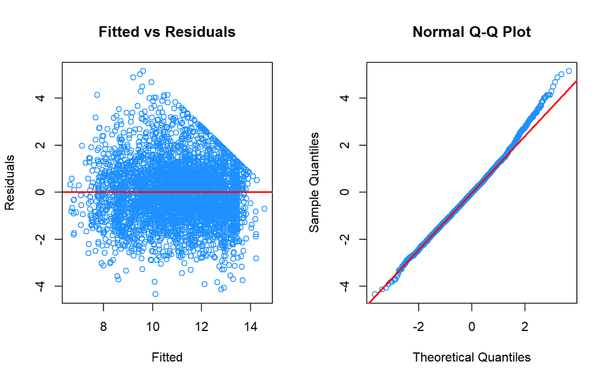

Figure 9 - Residuals vs Fitted and Normal QQ Plot for the model obtained from backward BIC search

```r
assumption_test(large_model_trans_back_bic)
```

```r
large_model_trans_back_bic_prediction = ((inter_lambda * predict(large_model_trans_back_bic, newdata = lcf_tst_data))+1)^(1/inter_lambda)
large_model_trans_back_bic_prediction_diff = (lcf_tst_data[,"expenditure"]-large_model_trans_back_bic_prediction)/lcf_tst_data[,"expenditure"]
```

The plot of the difference between the `expenditure` value predicted by the model and the actual values are shown in figure 10.

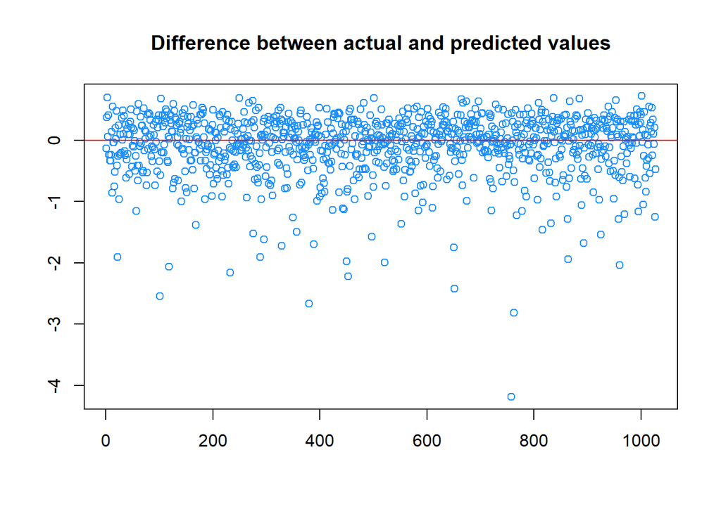

Figure 10 - difference between predicted and actual values

### Comparing the models

The RMSE for the additive model and the interaction model are

| Model | RMSE on training data | RMSE on test data |
| --- | --- | --- |
| Additive | 199.7327109 | 206.3716797 |
| Interaction | 547.1720874 | 205.7076504 |

## Results

```r
summary(lcf_data$expenditure)
```

```
##    Min. 1st Qu.  Median    Mean 3rd Qu.    Max.
##   30.52  246.24  402.44  443.55  595.06 1172.36
```

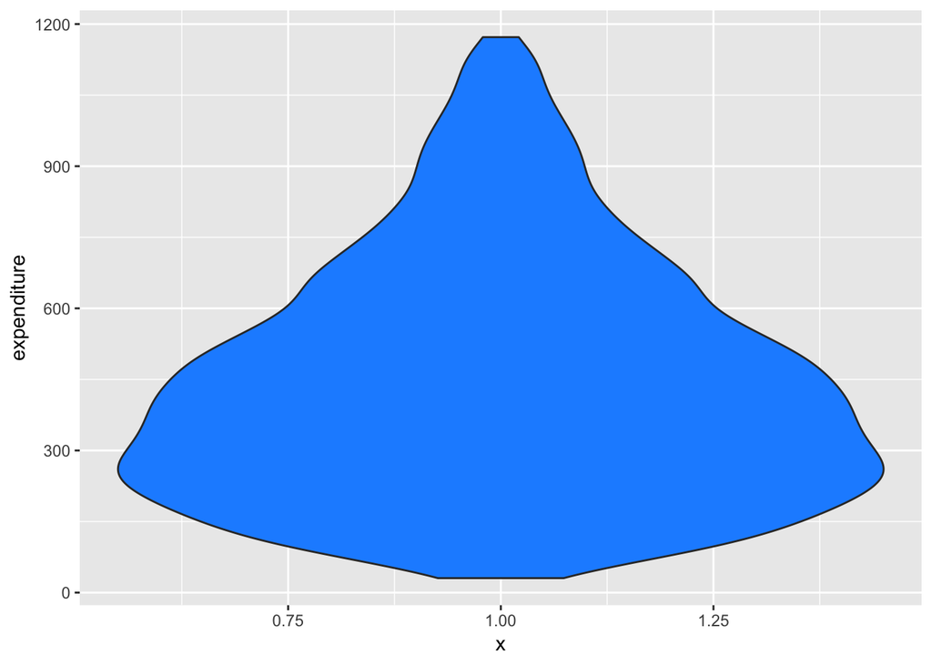

```r
ggplot(lcf_data,aes(y=expenditure,x=1))+geom_violin(fill="dodgerblue")
```

```r
#pairs(lcf_data)
```

```r
cor(lcf_data$hhsize,lcf_data$noPersons)
```

```
## [1] 1
```

```r
sum(!lcf_data$hhsize == lcf_data$noPersons)
```

```
## [1] 0
```

Both variables are exactly same , removing `noPersons`

```r
lcf_data$noPersons=NULL
```

```r
# This function takes the model as the input and test
# a) Normality
# b) Linearity
# c) Constant variance
assumption_test = function(model){
  par(mfrow=c(1,2))

  # Fitted vs residual plot
  plot(fitted.values(model),resid(model),col="dodgerblue")
  abline(h=0,col="red",lwd=2)

  # QQ plot to test normality
  qqnorm(resid(model),col="dodgerblue")
  qqline(resid(model),lwd=2,col="red")

  #print(paste("Shapiro-Wilk normality test :",shapiro.test(sample(resid(model),500,replace=FALSE))$p.value))
  #print(paste("BP test for constant variance :",bptest(model)$p.value))
}
```

lets create a additive model first

```r
model = lm(expenditure ~ ., data = lcf_data)
summary(model)
```

```
##
## Call:
## lm(formula = expenditure ~ ., data = lcf_data)
##
## Residuals:
##     Min      1Q  Median      3Q     Max
## -513.72 -106.72  -23.88   81.25  879.96
##
## Coefficients:
##                          Estimate Std. Error t value Pr(>|t|)
## (Intercept)             117.17081   19.34618   6.057 1.50e-09 ***
## noAdults2                44.35352   13.71332   3.234  0.00123 **
## noAdults3                55.91364   25.78257   2.169  0.03016 *
## noAdults4                65.47442   39.00336   1.679  0.09328 .
## NoChildrenOneChild       -5.04175   14.20651  -0.355  0.72269
## NoChildrenTwoOrMore     -22.66253   27.50731  -0.824  0.41005
## income                    0.35340    0.01133  31.190  < 2e-16 ***
## hhsize                   33.22659   11.90031   2.792  0.00526 **
## incomeSourceOtherIncome  15.95529    9.09092   1.755  0.07931 .
## internetYes              65.40215    7.24001   9.033  < 2e-16 ***
## economicHRPFullTime     -15.89284   12.46248  -1.275  0.20228
## economicHRPPartTime       3.28251   12.71108   0.258  0.79623
## economicHRPUnemployed   -36.37805   16.67723  -2.181  0.02921 *
## SEC3ClassClass2         -19.62120    8.46337  -2.318  0.02047 *
## SEC3ClassClass3         -60.65099    7.84711  -7.729 1.31e-14 ***
## SEC3ClassClass4         -68.51416   15.86895  -4.317 1.61e-05 ***
## SEC3ClassClass5         -66.26978   11.49960  -5.763 8.78e-09 ***
## tenureTypePrivateRented  20.35007    7.27909   2.796  0.00520 **
## tenureTypePublicRented  -41.13778    7.27294  -5.656 1.64e-08 ***
## sex_HRPMale               6.79403    5.51665   1.232  0.21818
## ---
## Signif. codes:  0 '***' 0.001 '**' 0.01 '*' 0.05 '.' 0.1 ' ' 1
##
## Residual standard error: 170.6 on 4856 degrees of freedom
## Multiple R-squared:  0.5423, Adjusted R-squared:  0.5405
## F-statistic: 302.9 on 19 and 4856 DF,  p-value: < 2.2e-16
```

Selecting only the important variables

```r
model = lm(expenditure ~ income + internet + tenureType + SEC3Class + hhsize, data = lcf_data)

summary(model)
```

```
##
## Call:
## lm(formula = expenditure ~ income + internet + tenureType + SEC3Class +
##     hhsize, data = lcf_data)
##
## Residuals:
##     Min      1Q  Median      3Q     Max
## -511.40 -108.37  -24.36   84.14  898.25
##
## Coefficients:
##                          Estimate Std. Error t value Pr(>|t|)
## (Intercept)             106.41225   11.06883   9.614  < 2e-16 ***
## income                    0.37084    0.00997  37.196  < 2e-16 ***
## internetYes              71.31304    7.24158   9.848  < 2e-16 ***
## tenureTypePrivateRented  15.86855    7.29211   2.176   0.0296 *
## tenureTypePublicRented  -46.39946    7.24859  -6.401 1.69e-10 ***
## SEC3ClassClass2         -14.83793    8.44044  -1.758   0.0788 .
## SEC3ClassClass3         -50.75733    7.74400  -6.554 6.17e-11 ***
## SEC3ClassClass4         -58.41150   14.41353  -4.053 5.15e-05 ***
## SEC3ClassClass5         -31.09625    7.74896  -4.013 6.09e-05 ***
## hhsize                   38.38556    2.46824  15.552  < 2e-16 ***
## ---
## Signif. codes:  0 '***' 0.001 '**' 0.01 '*' 0.05 '.' 0.1 ' ' 1
##
## Residual standard error: 171.8 on 4866 degrees of freedom
## Multiple R-squared:  0.5346, Adjusted R-squared:  0.5338
## F-statistic: 621.1 on 9 and 4866 DF,  p-value: < 2.2e-16
```

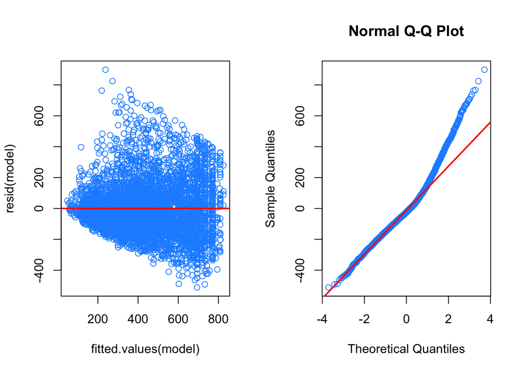

```r
assumption_test(model)
```

### Log Transformation

```r
model_log = lm(log(expenditure)~income + internet + tenureType + SEC3Class + hhsize, data = lcf_data)
summary(model_log)
```

```
##
## Call:
## lm(formula = log(expenditure) ~ income + internet + tenureType +
##     SEC3Class + hhsize, data = lcf_data)
##
## Residuals:
##      Min       1Q   Median       3Q      Max
## -1.70947 -0.26345  0.01128  0.26857  1.54985
##
## Coefficients:
##                           Estimate Std. Error t value Pr(>|t|)
## (Intercept)              4.935e+00  2.722e-02 181.316  < 2e-16 ***
## income                   8.987e-04  2.452e-05  36.656  < 2e-16 ***
## internetYes              3.205e-01  1.781e-02  17.997  < 2e-16 ***
## tenureTypePrivateRented  5.099e-02  1.793e-02   2.844  0.00448 **
## tenureTypePublicRented  -1.839e-01  1.782e-02 -10.318  < 2e-16 ***
## SEC3ClassClass2          1.868e-02  2.076e-02   0.900  0.36818
## SEC3ClassClass3         -6.008e-02  1.904e-02  -3.155  0.00161 **
## SEC3ClassClass4         -2.423e-01  3.544e-02  -6.837 9.11e-12 ***
## SEC3ClassClass5         -5.475e-02  1.906e-02  -2.873  0.00408 **
## hhsize                   1.035e-01  6.070e-03  17.057  < 2e-16 ***
## ---
## Signif. codes:  0 '***' 0.001 '**' 0.01 '*' 0.05 '.' 0.1 ' ' 1
##
## Residual standard error: 0.4225 on 4866 degrees of freedom
## Multiple R-squared:  0.5824, Adjusted R-squared:  0.5816
## F-statistic:   754 on 9 and 4866 DF,  p-value: < 2.2e-16
```

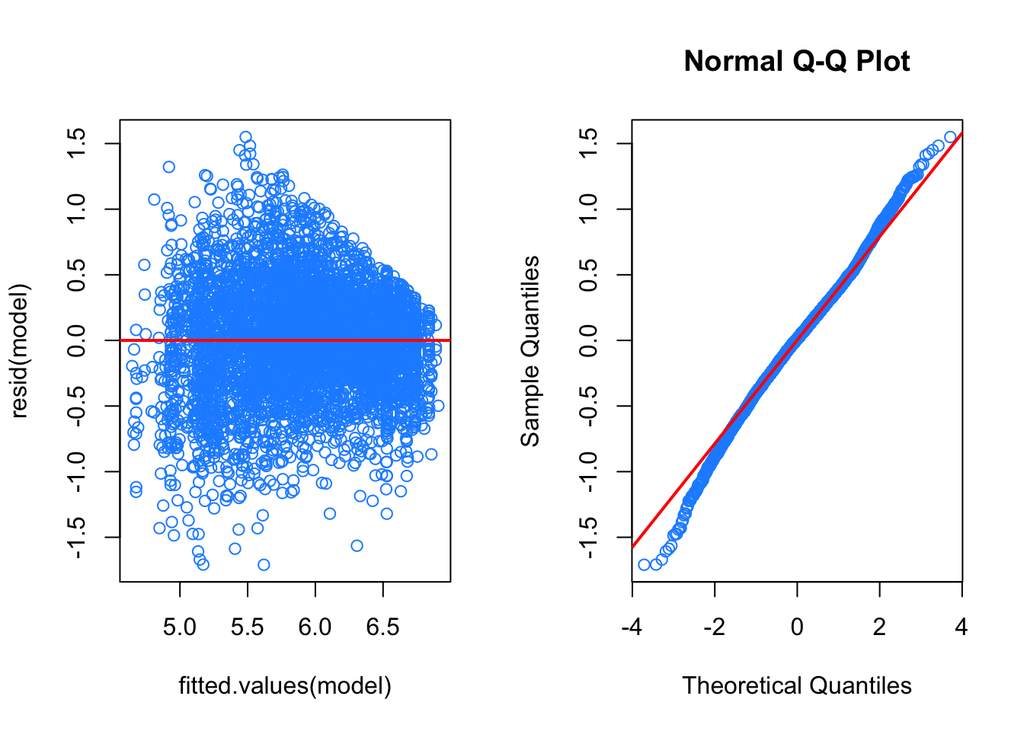

```r
assumption_test(model_log)
```

### BoxCox Transformation

```r
library(MASS)
model =lm(expenditure ~ income + internet + tenureType + SEC3Class + hhsize, data = lcf_data)
bc=boxcox(model,lambda = seq(-3,3))
```

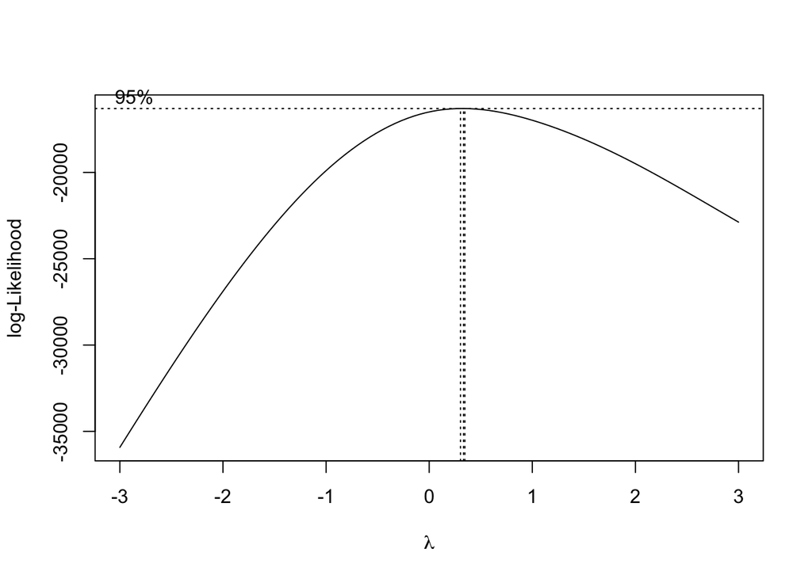

```r
(lambda = best_lambda = bc$x[which(bc$y==max(bc$y))])
```

```
## [1] 0.3333333
```

```r
model = lm(expenditure^lambda ~  income +internet + hhsize + tenureType+SEC3Class, data = lcf_data)
summary(model)
```

```
##
## Call:
## lm(formula = expenditure^lambda ~ income + internet + hhsize +
##     tenureType + SEC3Class, data = lcf_data)
##
## Residuals:
##     Min      1Q  Median      3Q     Max
## -3.4208 -0.6669 -0.0394  0.6027  4.1930
##
## Coefficients:
##                           Estimate Std. Error t value Pr(>|t|)
## (Intercept)              5.135e+00  6.252e-02  82.134  < 2e-16 ***
## income                   2.167e-03  5.631e-05  38.478  < 2e-16 ***
## internetYes              6.318e-01  4.090e-02  15.447  < 2e-16 ***
## hhsize                   2.386e-01  1.394e-02  17.116  < 2e-16 ***
## tenureTypePrivateRented  1.119e-01  4.119e-02   2.717 0.006609 **
## tenureTypePublicRented  -3.709e-01  4.094e-02  -9.058  < 2e-16 ***
## SEC3ClassClass2         -4.644e-03  4.768e-02  -0.097 0.922407
## SEC3ClassClass3         -2.024e-01  4.374e-02  -4.627 3.81e-06 ***
## SEC3ClassClass4         -4.805e-01  8.141e-02  -5.902 3.84e-09 ***
## SEC3ClassClass5         -1.544e-01  4.377e-02  -3.527 0.000424 ***
## ---
## Signif. codes:  0 '***' 0.001 '**' 0.01 '*' 0.05 '.' 0.1 ' ' 1
##
## Residual standard error: 0.9705 on 4866 degrees of freedom
## Multiple R-squared:  0.5838, Adjusted R-squared:  0.583
## F-statistic: 758.3 on 9 and 4866 DF,  p-value: < 2.2e-16
```

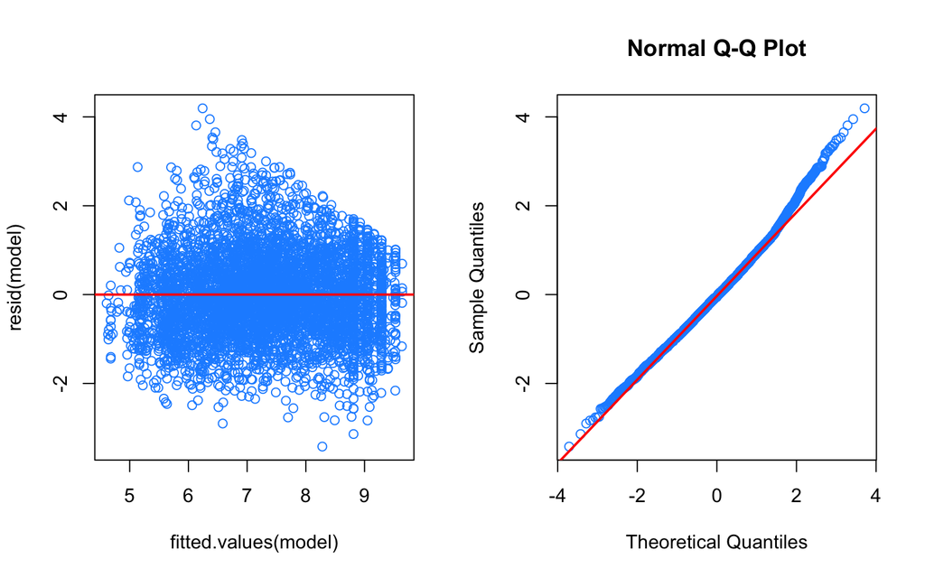

```r
assumption_test(model)
```

Fitted Vs Residual plot looks ok

```r
coef(summary(model))
```

```
##                             Estimate   Std. Error     t value
## (Intercept)              5.135149282 6.252125e-02 82.13446703
## income                   0.002166879 5.631477e-05 38.47798791
## internetYes              0.631849446 4.090337e-02 15.44736882
## hhsize                   0.238620909 1.394164e-02 17.11570318
## tenureTypePrivateRented  0.111914834 4.118879e-02  2.71711869
## tenureTypePublicRented  -0.370870502 4.094299e-02 -9.05821657
## SEC3ClassClass2         -0.004643875 4.767504e-02 -0.09740684
## SEC3ClassClass3         -0.202390816 4.374127e-02 -4.62699903
## SEC3ClassClass4         -0.480497985 8.141347e-02 -5.90194717
## SEC3ClassClass5         -0.154379468 4.376928e-02 -3.52711931
##                              Pr(>|t|)
## (Intercept)              0.000000e+00
## income                  4.882735e-283
## internetYes              1.368184e-52
## hhsize                   8.097369e-64
## tenureTypePrivateRented  6.608602e-03
## tenureTypePublicRented   1.882381e-19
## SEC3ClassClass2          9.224073e-01
## SEC3ClassClass3          3.806368e-06
## SEC3ClassClass4          3.835793e-09
## SEC3ClassClass5          4.239835e-04
```

```r
set.seed(420)
no_of_obs = nrow(lcf_data)

idx = sample(no_of_obs,no_of_obs*.80)

train = lcf_data[idx,]
test = lcf_data[-idx,]
```

```r
model_train = lm(expenditure^lambda ~  income +internet + hhsize + tenureType+SEC3Class, data = train)


# Train RMSE
sqrt(mean((predict(model_train)^(1/lambda) - train$expenditure)^2))
```

```
## [1] 175.3436
```

```r
# Test RMSE
sqrt(mean((predict(model_train,newdata = test)^(1/lambda) - test$expenditure)^2))
```

```
## [1] 169.4666
```

## References

<sup>1</sup> University of Manchester, Cathie Marsh Institute for Social Research (CMIST), UK Data Service, Office for National Statistics. (2019). Living Costs and Food Survey, 2013: Unrestricted Access Teaching Dataset. [data collection]. 2nd Edition. Office for National Statistics, [original data producer(s)]. Office for National Statistics. SN: 7932, http://doi.org/10.5255/UKDA-SN-7932-2

<sup>2</sup> Organisation for Economic Co-operation and Development. “Household Accounts - Household Spending”. oecd.org. https://data.oecd.org/hha/household-spending.htm (Accessed July 21st 2019).

<sup>3</sup> D. Ferguson, B & Tandon, A & Gakidou, E & J. L. Murray, C. (2010). Estimating Permanent Income Using Indicator Variables. Health Systems Performance Assessment: Debates, Methods and Empiricism.